# Why do we study genetic variations?

- Single nucleotide polymorphism (SNP) - most common type of genetic variations among human
- Each SNP is a single change in DNA building block (nucleotide)

Exsample:

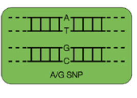

- ~10 million SNPs in a human genome
- Very important for human health

### SNP distribution

- On average, a snp is found in once in every 300 nucleotides
- SNP distribution is non-random
- Knowledge in SNP distribution is useful for studies in :

  ```
  -Identifying regions causing diseases like cancer
  -Evolution
  -Population histories
  ```

- Current tools for visualizing SNP distribution need prior knowledge in R or other scripting languages
- Many biologists lack such knowledge

### Shiny app for SNP distribution

- Web-based, easy to use and require no prior knowledge in advance computational methods or languages
- Bin the SNP distribution into user defined windows
- Set threshold for the cumulative number of SNPs in each window
- Graphically display the output in an elegant plot using ggplot in r
- Provide basic statistics about SNP distribution

Table below shows typical SNP table (Chrom: name of chromosome; chromStrat: position of the SNP)

```r
library(Hmisc)
snps<-read.table("snp_head.bed",sep="\t",header=T)
head(snps)[1:2][1:3,]
```

```
  chrom chromStart
1  chr1      10582
2  chr1      10610
3  chr1      13301
```

### Finding SNP density in different region of the genome

Following function in the app will generate the SNP density for different regions of the genome

```r
snps$snp <- 1
ch06_2 <- aggregate(snps$snp, list(cut2(snps$chromStart, cuts=seq(min(snps$chromStart), max(snps$chromStart), by = 100000#user can set in the app
                                                                  ))),FUN = "sum")
colnames(ch06_2) <- c("Genomic_region", "Number_of_SNPs")
head(ch06_2)[1:3,]
```

```
     Genomic_region Number_of_SNPs
1 [  10582, 110582)            116
2 [ 110582, 210582)             23
3 [ 210582, 310582)             14
```

### Visualization of the results and future implementations

Following graph shows the distribution of SNP density across a chromosome

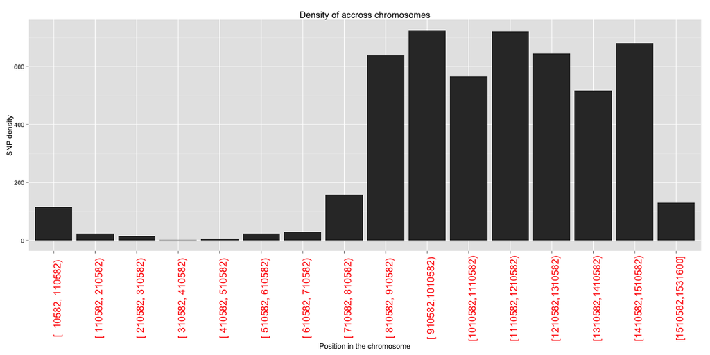

## Need to be done:

-Import and export data

-Implement a statistical analysis to find SNP enriched regions

-Expand to include other chromosomes